# Exploration of Corpora for Predictive Text Entry

A. Nugent, data-products

20 March 2016

# Environment

## Packages installed

- ggplot2
- wordcloud
- RColorBrewer
- readr
- tm
- RWeka

# Purpose

This document summarises the data cleaning and exploratory analysis that has been applied to the input data provided for developing a predictive algorithm for text entry.

Three data files (or “corpora”) are considered: a sample of US news hoighlights, a sample of US blogs entries, and a sample of US Twitter tweets.

# Preprocessing of Raw Data

## Data input

When trying to read the file “en_US.news.txt”“, the R base function readLines caused truncation of the input file at the occurrence of the soft EOF (”SUB“) character (unicode 001A); therefore, that file and the”en_US.news.txt" file were read in binary mode using the read_lines function from the readr package. Conversely, the “en_US.twitter.txt” was read using readLines to avoid an error thrown by read_lines.

## Gross features of input data

```
##               News        Blogs       Twitter
##  size:        196.3       200.4       159.4
##  lines:       1010243     899289      2360149
```

## Data cleaning assumptions, decisions, and implications

It was assumed that the following would add little value in exchange for considerable difficulty:

- discrminate between contractions, possession, single quotes;
- predict or genericise quantities and currency amounts;
- predict end of sentence / punctuation;
- recognise URLs;
- predict case.

Also, it was decided not to support languages other than English, as expert knowledge in the available options was lacking. (Ultimately, the product should only support one language at a time, anyway.)

It was decided, however, that the intention of profanities should be captured – if not the profanities themselves – in order to preserve nuance.

Therefore, the following actions and assumptions were implicit:

- only the english-language data files would be used
- preserve apostrophes in contractions but remove from word and sentance boundaries
- preserve hyphens in compound words
- delete all other punctuation
- delete numbers
- delete “$”
- the most profane words would be replaced by a special flag word.

Data cleaning was applied using custom code developed by trial and error on all three input files. The following methodology was adopted:

1. replace unicode apostrophe, curly single quotes with ASCII apostrophe:
2. replace backtick with ASCII apostrophe:
3. delete minus sign, dash (preceding space)
4. remove all but letters, spaces, apostrophes, hyphens:
5. collapse multiple space chars (do this 2nd last!):
6. remove apostrophes used as single-quotes (i.e. at word and line boundaries):
7. convert to lower case:
8. replace profanities with the proxy “zark” (in deference to the late Douglas Adams).

# Processing and Profiling of Corpora

Computing the term-dcument matrix (TDM) on one entire corpus (the cleaned en_US news file) required several hours. Attemting to compute the TDM for word doublets in this file produced an error that was interpreted as a memory limitation. Therefore, bar the use of a distributed computing platform, sampling of the data would be essential. Various experiments were then performed to assess the available sampling constraints – namely, data source, sample size, and sampling method.

## Corpus sizes

The resulting counts of total and unique words for each sample size (US news only). The locations at which counts fell to 1 and 2 were determined, and are given below as “tail” and “frac”, respectively, in the table shown below.

```
##           1%          10%         100%
##  total:   343527      3410551     34003876
##  unique:  29156       90730       268628
##  tail 1:  14570       49236       144640
##  frac 1:  0.4997      0.5427      0.5384
##  tail 2:  10234       36977       111045
##  frac 2:  0.351       0.4075      0.4134
```

It appears that a factor of 10 increase in corpus size results in only a factor of 3 increase in the number of unique words. Furthermore, roughly 50% of words occur ore than once and 40% more than twice, regardless of sample size.

## Effect of sample size on gross word distribution

Word clouds of the 500 most frequent words for 1% and 10 % sampling are shown below.

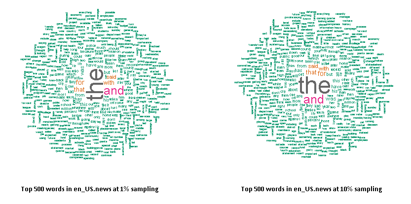

These graphics highlight the preponderance of the most common words, which are identical for 1% and 10% sample sizes.

## Effect of sample size on incidence of misspelling

The frequency of non-dictionary words was chosen as a proxy for that of misspelled words. This approach also filters out proper nouns, common abbreviations, and borrowings from foreign languages, but it is practical in light of the ultimate goal. Word counts were obtained from term-document matrices computed from samples of all three data sources (news at 1% and 10% sampling density, blogs and twitter at 1% sampling).

The total word counts and the number and proportion of misspelled words, versus sample size and data source, were as follows.

```
##                   words       misspellings    fraction
##  US news 10%      2778404     159853          0.0575
##  US news 1%        280085      16150          0.0577
##  US blogs 1%       285055      12416          0.0436
##  twitter 1%        226294      22116          0.0977
```

## Effect of sample size on N-gram distributions

Term-document matrices were computed for doublets and triplets in the news source (at 1% and 10% sampling density) and ordered by frequency (descending). The numbers of these N-grams arising from each sample size are tabulated below.

```
##              1%       10%
##  doublets:   188235   1133648
##  triplets:   292764   2420849
```

Inspection of doublets with frequency = 1 suggested that very low value would be achieved by including these in the predictive model, as most seemed to be either grammar/spelling s errors (e.g. “a apples”) or uncommon juxtapositions (e.g. “asphalt surface”).

Frequency plots of the first 50,000 doublets are shown below (all unplotted doublets have a frequency of 1). Frequencies are represented as the natural logarithm of the N-gram count.

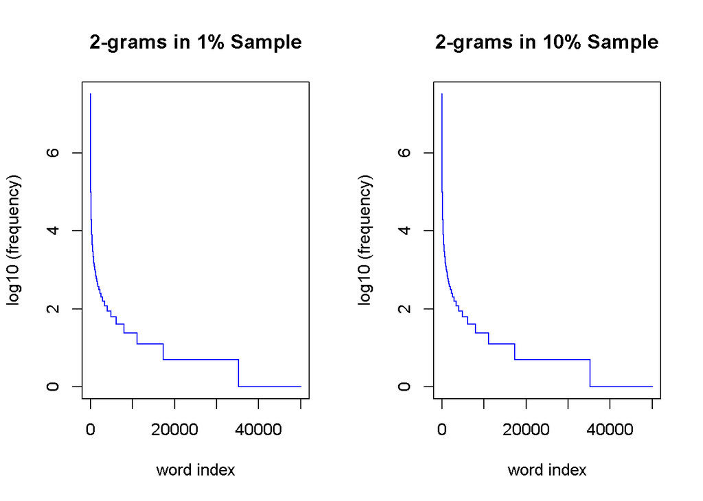

Frequency plots of the first 50,000 triplets are shown below (all unplotted triplets have a frequency of 1). Frequencies are represented as the natural logarithm of the N-gram count.

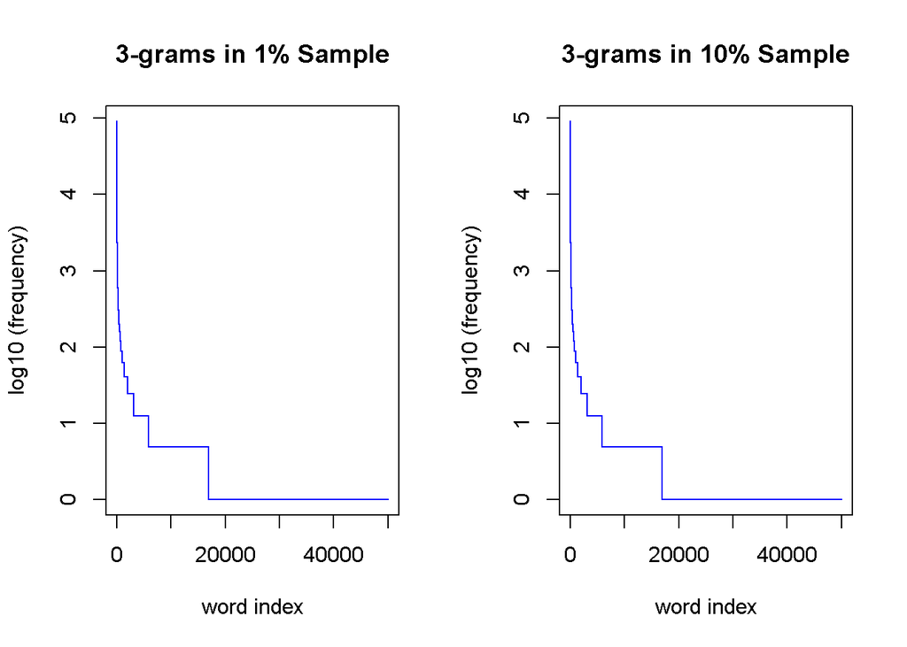

Visually, there is almost no difference between the 1% and 10% cases, implying that conservative sampling will yield effective coverage.

## Effect of sampling method on N-gram distributions

TDMs were computed for doublets (2-grams) in two data samples of 1% each, one derived sequentially and one randomly. The TDMs were subsetted at minimum doublet frequencies of 2 and 10. The similarities between the truncated doublet distributions were compared between the sequential and random sampling methods by computing the fraction of each set that was not contained in the other. The results are tabulated below.

```
##              n > 1    missing     n > 9   missing
##  Random:     34717    0.5115      2992    0.0191
##  Sequential: 35226    0.5044      2899    0.0221
```

Evidently, although the membership of very low-frequency doublets is strongly dependent on sampling, that of moderately low-frequency doublets is not. It was concluded that the raw data were sufficiently randomised to justify sequential sampling (allowing faster input operations).

# Tentative Recommendations

## Selection and sampling of corpus

Unless further investigation dictates otherwise, the system shall be trained on the English US news data set, sampled sequentially at a density of 10%. This shall be reduced ot 1% (or a compromise between) if 10% proves to be computationally impractical.

## N-gram frequency cut-offs

The optimal cut-off for a 2-gram and 3-gram TDMs remains to be determined; it appears to be is between 2 and 10 for doublets (based on the 1%-sampled, 2-gram TDM). The distribution of triplet frequencies falls off much faster, so its optimal cut-off frequency will likely be higher than that for the doublets.

## Strategy for using N-gram matrices for prediction

To speed model training and the performance of the ultimate product, the 2-gram and 3-gram TDMs shall be truncated at appropriate word frequencies, which will probably be between 3 and 10. The prediction algorithm will be based on the 3-gram TDM, but for user-entered 3-grams that are not contained in the TDM the algorithm will revert to the 2-gram TDM. A strategy is required for occasions when the 2-gram TDM also fails to match the user’s entry.